# Plotting functions

Francois Keck

2023-10-12

The `phylosignal` package comes with functions designed to plot trait values and phylogeny together. These functions are generics for `phylo4d` objects. This document present how to use them.

## Data

```r
library(ape)
library(adephylo)
library(phylobase)
library(phylosignal)
data(carni19)
```

Here is a phylogenetic tree of 19 carnivora species.

```r
tre <- read.tree(text = carni19$tre)
```

And we create a dataframe of 3 traits for the 19 carnivora species. - Body mass - Random values - Simulated values under a Brownian Motion model along the tree

```r
dat <- data.frame(carni19$bm)
dat$random <- rnorm(dim(dat)[1], sd = 10)
dat$bm <- rTraitCont(tre)
```

We can combine phylogeny and traits into a `phylo4d` object.

```r
p4d <- phylo4d(tre, dat)
```

## Basics

Once we have a `phylo4d` object, we can plot it… There are three plotting functions: `barplot`, `dotplot` and `gridplot`. These functions are actually wrappers of the function `multiplot.phylo4d`.

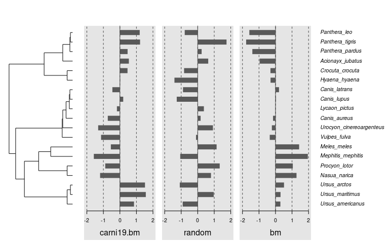

```r
barplot(p4d)
```

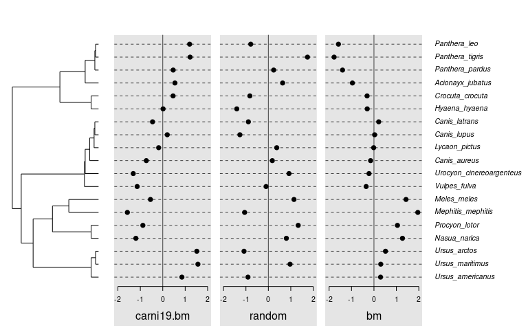

```r
dotplot(p4d)
```

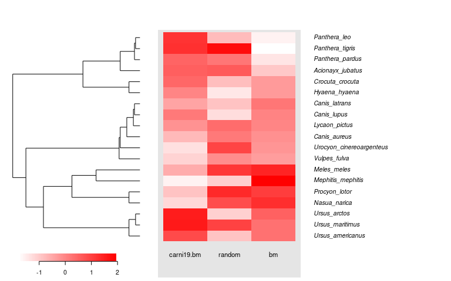

```r
gridplot(p4d)
```

Each of these functions can be used with one of the 3 tree styles: `phylogram`, `cladogram` and `fan`. For example, here is a dotplot with a cladogram.

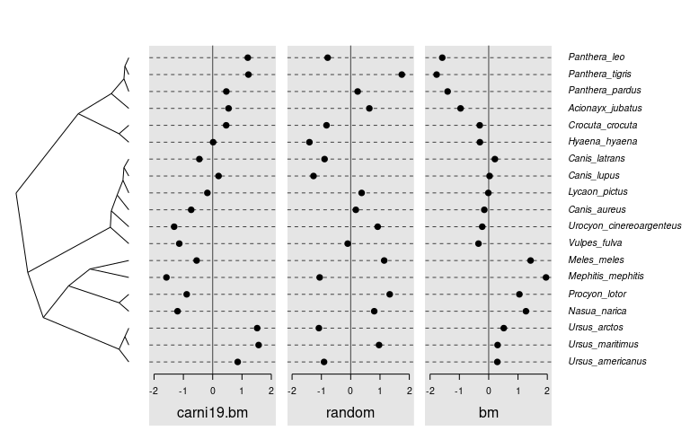

```r
dotplot(p4d, tree.type = "cladogram")
```

And here a gridplot with a fan tree.

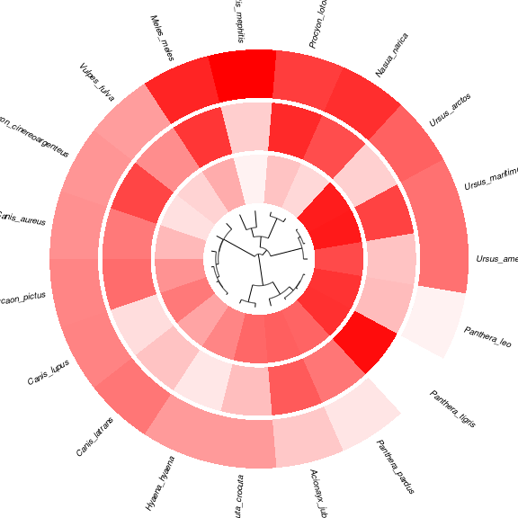

```r
gridplot(p4d, tree.type = "fan", tip.cex = 0.6, show.trait = FALSE)
```

Select the ratio of the plot occupied by the tree.

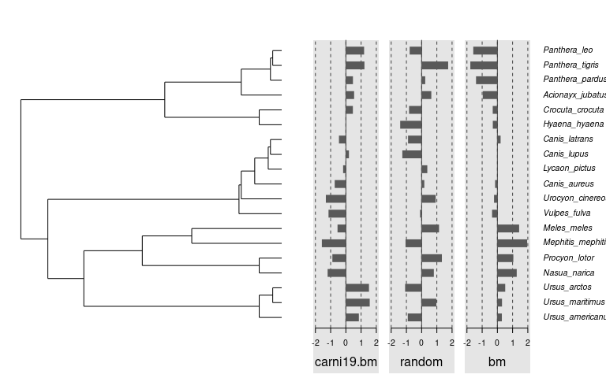

```r
barplot(p4d, tree.ratio = 0.5)
```

Control which traits to plot and their order.

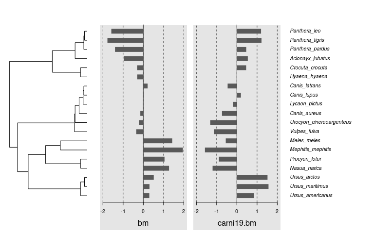

```r
barplot(p4d, trait = c("bm", "carni19.bm"))
```

Add simple error bars.

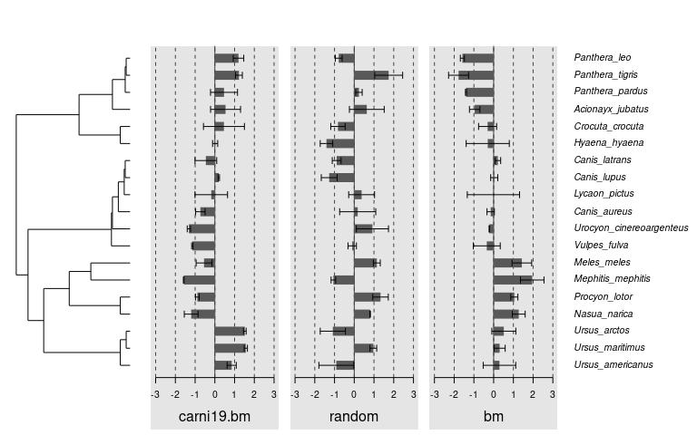

```r
mat.e <- matrix(abs(rnorm(19 * 3, 0, 0.5)), ncol = 3,
                dimnames = list(tipLabels(p4d), names(tdata(p4d))))
barplot(p4d, error.bar.sup = mat.e, error.bar.inf = mat.e)
```

It is also possible to open a fan tree with a specified angle.

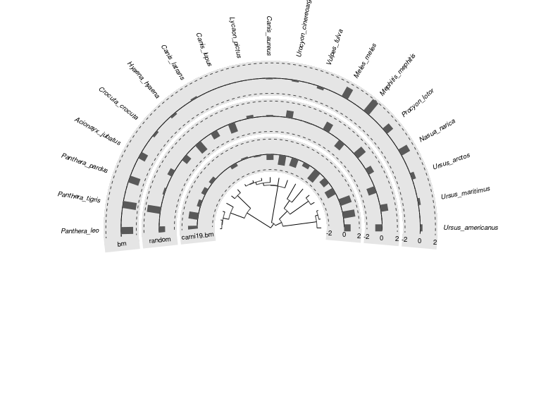

```r
barplot(p4d, tree.type = "fan", tip.cex = 0.6, tree.open.angle = 160, trait.cex = 0.6)
```

## Colors

It’s easy to color bars ‘by species’ with a vector.

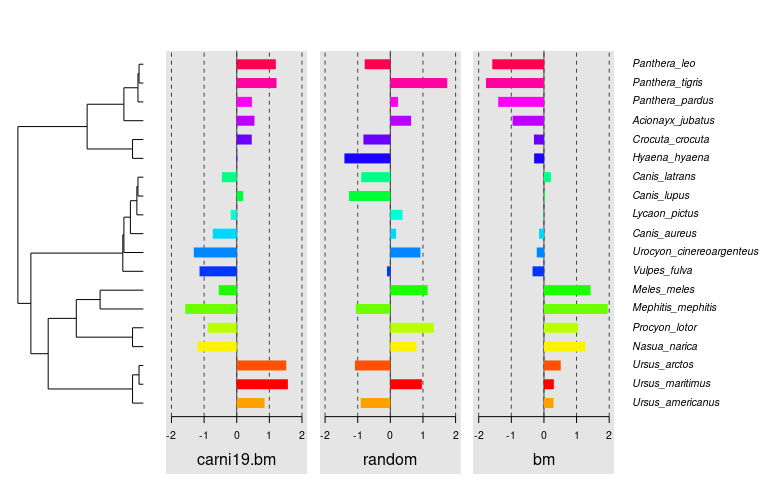

```r
barplot(p4d, bar.col = rainbow(19))
```

And for a finer control, one can use a matrix. Here, negative values in red.

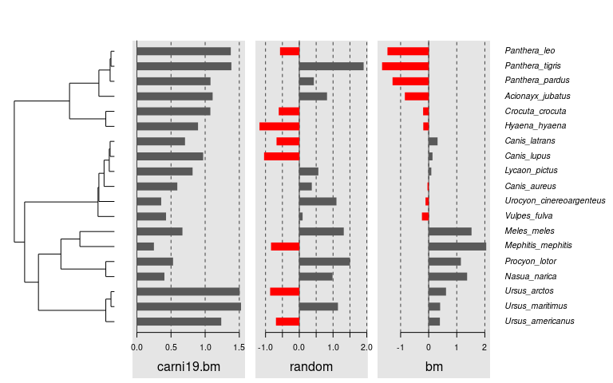

```r
mat.col <- ifelse(tdata(p4d, "tip") < 0, "red", "grey35")
barplot(p4d, center = FALSE, bar.col = mat.col)
```

Clearly identify traits with colored backgrounds:

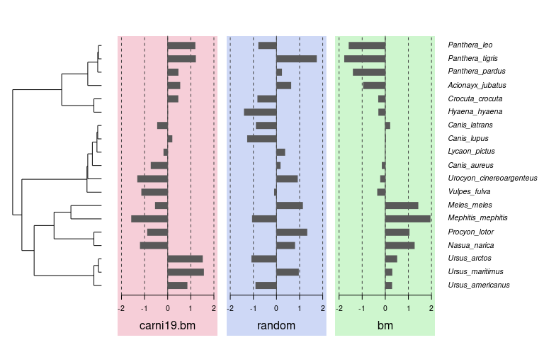

```r
barplot(p4d, trait.bg.col = c("#F6CED8", "#CED8F6", "#CEF6CE"), bar.col = "grey35")
```

For gridplots, cells are colored with a color palette, using the `cell.col` argument.

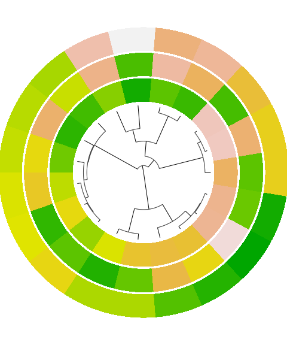

```r
gridplot(p4d, tree.type = "fan", tree.ratio = 0.5,
         show.trait = FALSE, show.tip = FALSE,
         cell.col = terrain.colors(100))
```

Combine arguments for sophisticated plots

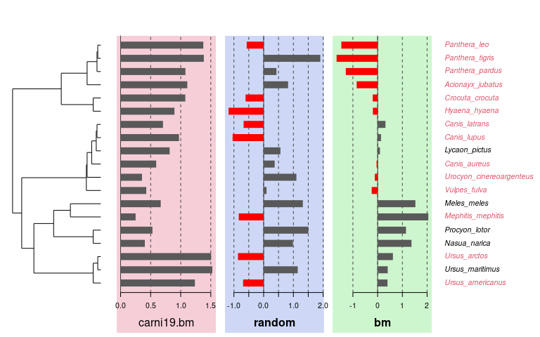

```r
tip.col <- rep(1, nTips(p4d))
tip.col[(mat.col[, 2] == "red") | (mat.col[, 3] == "red")] <- 2
barplot(p4d, center = FALSE, trait.bg.col = c("#F6CED8", "#CED8F6", "#CEF6CE"),
        bar.col = mat.col, tip.col = tip.col, trait.font = c(1, 2, 2))
```

You can control many other things. See `?multiplot.phylo4d` for more informations.

## Advanced tuning

In R, it is often possible to add graphical elements to a plot after drawing it (eg. with `points()`, `abline()`, etc.). This is also possible to use such functions with the plots generated with phylosignal. However, as plots are divided in regions (tree, data, tips), you need special functions to interactively browse among them. These functions are `focusTree`, `focusTraits`, `focusTips` and `focusStop`. Let’s see how we can use them.

Add a time scale bar to a tree

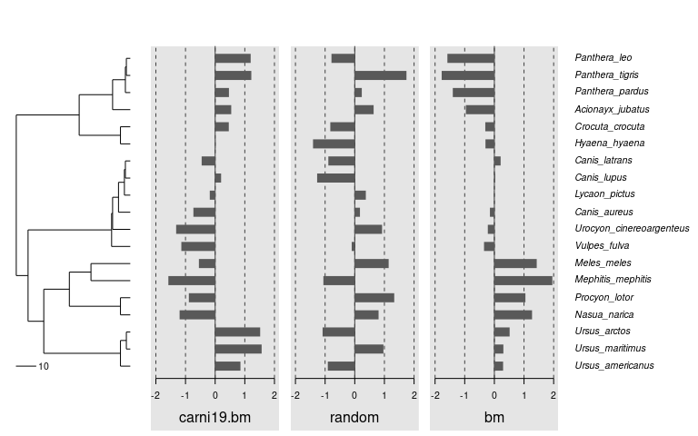

```r
barplot(p4d)
focusTree()
add.scale.bar()
```

Add a vertical red line to the 2nd trait

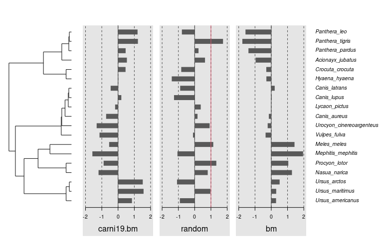

```r
barplot(p4d)
focusTraits(2)
abline(v = 1, col = 2)
```

Highlight the clade Ursus with a rectangle

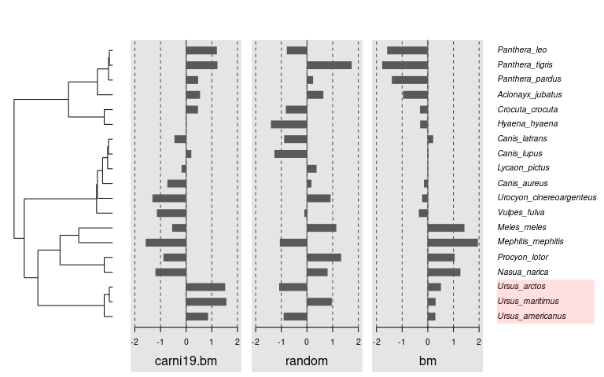

```r
barplot(p4d)
focusTips()
rect(xleft = 0, ybottom = 0.5,
     xright = 0.95, ytop = 3.5,
     col = "#FF000020", border = NA)
```